# IODS course project

Then turn boston_scaled back to being a data.frame

```r
boston_scaled <- as.data.frame(boston_scaled)
```

These lines give us a categorical variable crime

```r
bins <- quantile(boston_scaled$crim)
crime <- cut(boston_scaled$crim, breaks = bins, include.lowest = TRUE, labels = c("low", "med_low", "med_high", "high"))
```

And these replace the old crim with the categorical crime

```r
boston_scaled <- dplyr::select(boston_scaled, -crim)
boston_scaled <- data.frame(boston_scaled, crime)
```

Then we devide the data to train wiht 80% of the data and test with 20% of the data.

```r
n <- nrow(boston_scaled)
ind <- sample(n,  size = n * 0.8)
train <- boston_scaled[ind,]
test <- boston_scaled[-ind,]
```

5. Now we’ll create the LDA plot.

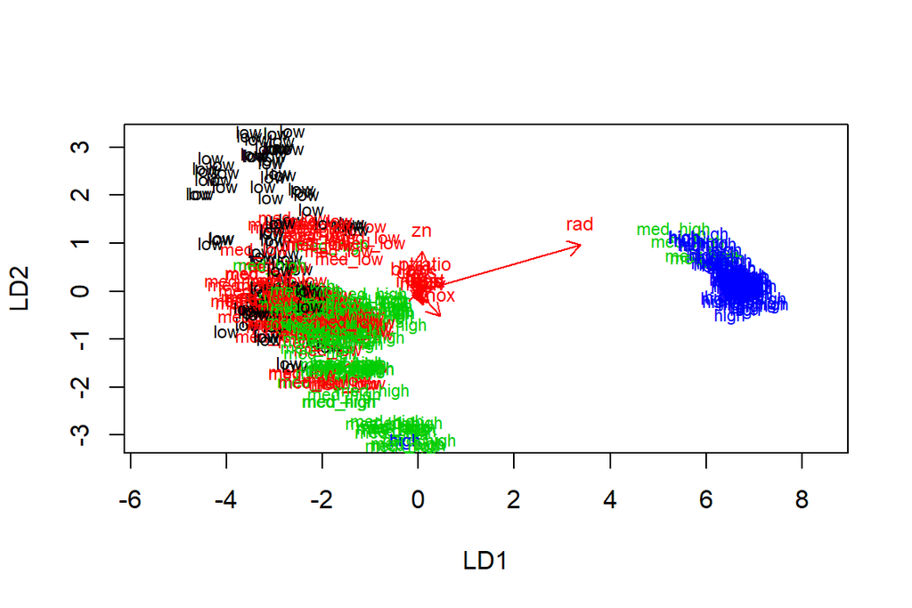

```r
lda.fit <- lda(crime ~ ., data = train)
lda.arrows <- function(x, myscale = 1, arrow_heads = 0.1, color = "red", tex = 0.75, choices = c(1,2)){
  heads <- coef(x)
  arrows(x0 = 0, y0 = 0,
         x1 = myscale * heads[,choices[1]],
         y1 = myscale * heads[,choices[2]], col=color, length = arrow_heads)
  text(myscale * heads[,choices], labels = row.names(heads),
       cex = tex, col=color, pos=3)
}
classes <- as.numeric(train$crime)
plot(lda.fit, dimen = 2, col=classes, pch=classes)
lda.arrows(lda.fit, myscale = 1)
```

A very cool plot appears.

6. Here’s the prediction of the LDA model on the test data.

```r
correct_classes <- test$crime
lda.pred <- predict(lda.fit, newdata = test)
table(correct = correct_classes, predicted = lda.pred$class)
```

```
##           predicted
## correct    low med_low med_high high
##   low       11       9        0    0
##   med_low   11      15        4    0
##   med_high   1       4       23    2
##   high       0       0        0   22
```

It appears that LDA model predicts the crime classes quite well.

7. Before we practice K-means clustering, we should reload the Boston data, scale it, and afterwards measure the distances between the observations.

```r
data(Boston)
boston_scaled1<-as.data.frame(scale(Boston))
dist_eu<-dist(boston_scaled1)
summary(dist_eu)
```

```
##    Min. 1st Qu.  Median    Mean 3rd Qu.    Max.
##  0.1343  3.4625  4.8241  4.9111  6.1863 14.3970
```

```r
head(boston_scaled1)
```

```
##         crim         zn      indus       chas        nox        rm
## 1 -0.4193669  0.2845483 -1.2866362 -0.2723291 -0.1440749 0.4132629
## 2 -0.4169267 -0.4872402 -0.5927944 -0.2723291 -0.7395304 0.1940824
## 3 -0.4169290 -0.4872402 -0.5927944 -0.2723291 -0.7395304 1.2814456
## 4 -0.4163384 -0.4872402 -1.3055857 -0.2723291 -0.8344581 1.0152978
## 5 -0.4120741 -0.4872402 -1.3055857 -0.2723291 -0.8344581 1.2273620
## 6 -0.4166314 -0.4872402 -1.3055857 -0.2723291 -0.8344581 0.2068916
##          age      dis        rad        tax    ptratio     black
## 1 -0.1198948 0.140075 -0.9818712 -0.6659492 -1.4575580 0.4406159
## 2  0.3668034 0.556609 -0.8670245 -0.9863534 -0.3027945 0.4406159
## 3 -0.2655490 0.556609 -0.8670245 -0.9863534 -0.3027945 0.3960351
## 4 -0.8090878 1.076671 -0.7521778 -1.1050216  0.1129203 0.4157514
## 5 -0.5106743 1.076671 -0.7521778 -1.1050216  0.1129203 0.4406159
## 6 -0.3508100 1.076671 -0.7521778 -1.1050216  0.1129203 0.4101651
##        lstat       medv
## 1 -1.0744990  0.1595278
## 2 -0.4919525 -0.1014239
## 3 -1.2075324  1.3229375
## 4 -1.3601708  1.1815886
## 5 -1.0254866  1.4860323
## 6 -1.0422909  0.6705582
```

The scaled Boston data will now be used for K-means clustering. It isn’t trivial (in many cases) to investigate on the number of clusters that can classify the data. Therefore, we need to first randomize the usage of a certain number of clusters.

```r
kmm = kmeans(boston_scaled1,6,nstart = 50 ,iter.max = 15)
```

The elbow method is one good technique using which we can estimate the number of clusters.

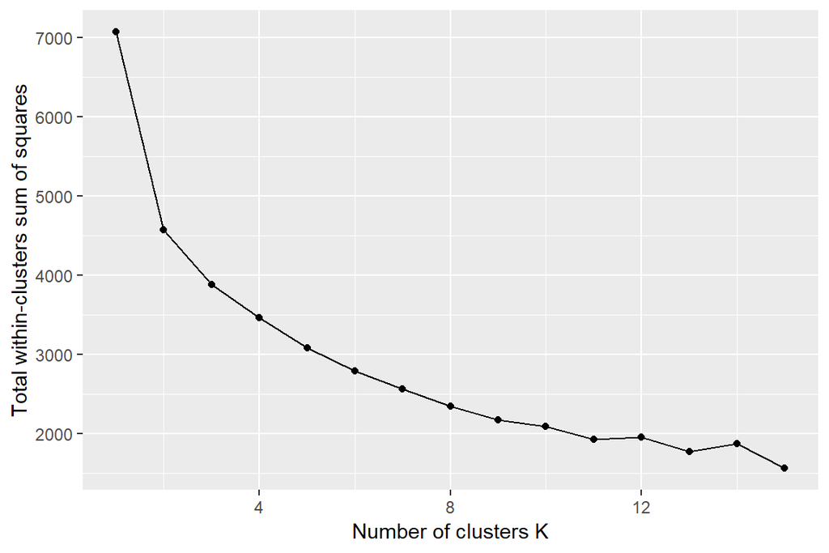

```r
library(ggplot2)
set.seed(1234)
k.max <- 15
data <- boston_scaled1
wss <- sapply(1:k.max,
              function(k){kmeans(data, k)$tot.withinss})
qplot(1:k.max, wss, geom = c("point", "line"), span = 0.2,
     xlab="Number of clusters K",
     ylab="Total within-clusters sum of squares")
```

The elbow plot seems to indicate that we may not find more than two clear clusters but it’s good to confirm predictions using another method because there is no shortage of methods for analyses like these. Let’s try the “NbClust”- package.

```r
library(NbClust)
nb <- NbClust(boston_scaled1, diss=NULL, distance = "euclidean",
              min.nc=2, max.nc=5, method = "kmeans",
              index = "all", alphaBeale = 0.1)
```

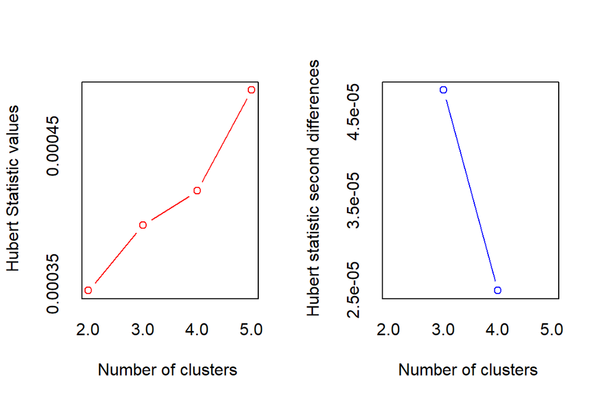

```
## *** : The Hubert index is a graphical method of determining the number of clusters.
##                 In the plot of Hubert index, we seek a significant knee that corresponds to a
##                 significant increase of the value of the measure i.e the significant peak in Hubert
##                 index second differences plot.
##
```

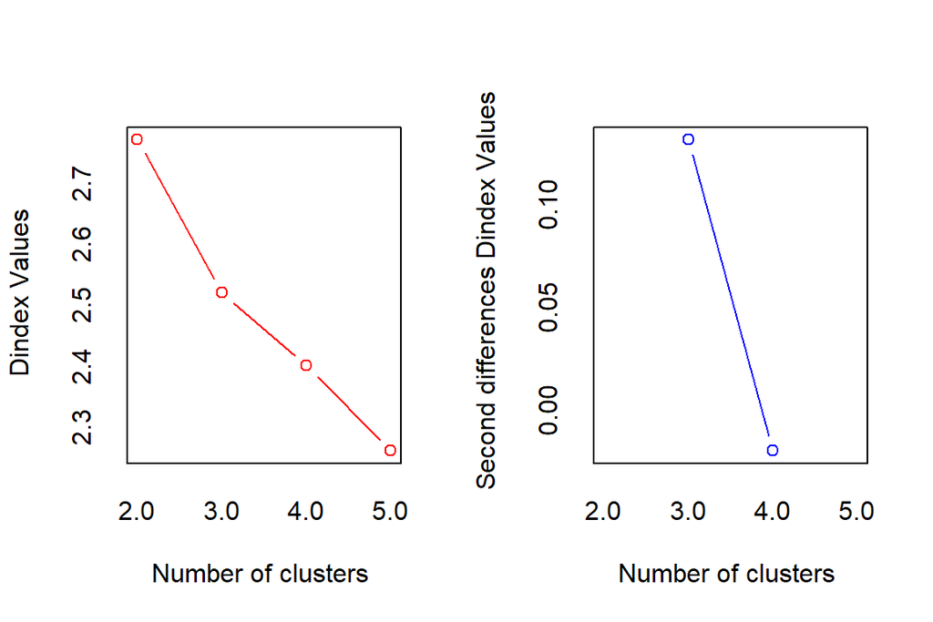

```
## *** : The D index is a graphical method of determining the number of clusters.
##                 In the plot of D index, we seek a significant knee (the significant peak in Dindex
##                 second differences plot) that corresponds to a significant increase of the value of
##                 the measure.
##
## * Among all indices:
## * 12 proposed 2 as the best number of clusters
## * 6 proposed 3 as the best number of clusters
## * 3 proposed 4 as the best number of clusters
## * 3 proposed 5 as the best number of clusters
##
##                    ***** Conclusion *****
##
## * According to the majority rule, the best number of clusters is  2
##
##
```

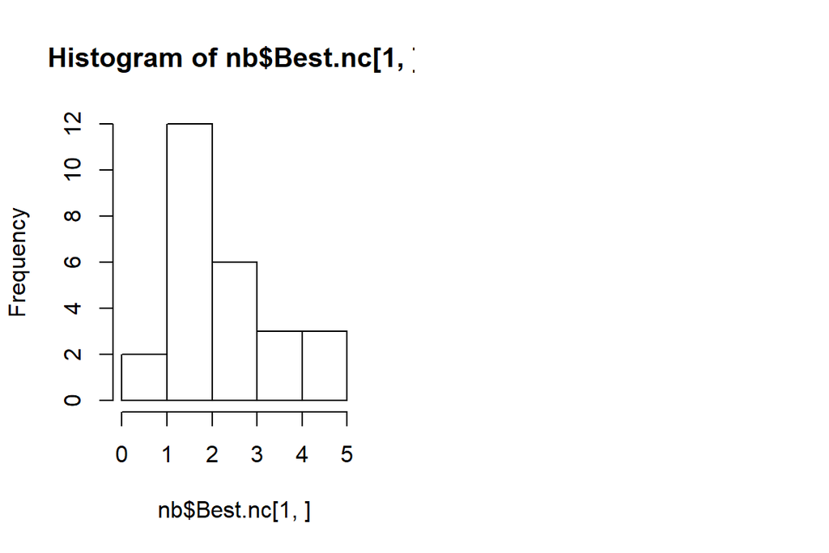

```r
hist(nb$Best.nc[1,], breaks = max(na.omit(nb$Best.nc[1,])))
```

Now, it’s easier to see that the data is described better with two clusters. With that, we should run the k-means algorithm again.

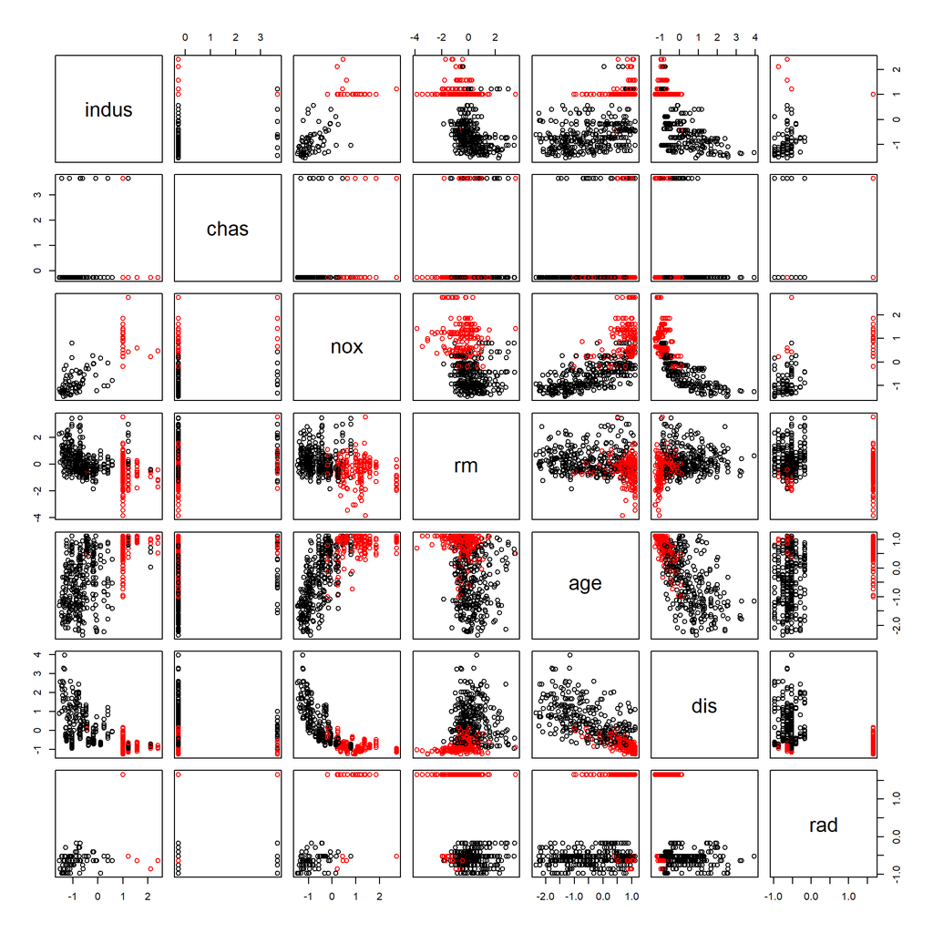

```r
km_final = kmeans(boston_scaled1, centers = 2)
pairs(boston_scaled1[3:9], col=km_final$cluster)
```

The clusters in the above plot are divided into two groups and outlined using the colors red and black. Some of the pairs are better grouped than other ones in the plot. One of the important observations can be made with the “chas”-variable where the observations in all of the pairs formed by it are wrongly clustered. Still, clusters formed by the “rad” variable are better separated.